# Example Groundwater Level Trend Analysis Workflow

This vignette illustrates one example of how to generate a reproducible trend analysis on B.C. groundwater level data using the `bcgroundwater` R package.

This example examines long-term trends in water level data from [British Columbia groundwater observation monitoring well #45](https://www2.gov.bc.ca/gov/content?id=2D3DB9BA78DE4377AB4AE2DCEE1B409B), using both the Mann-Kendall and Seasonal Kendall non-parametric trend tests, as implemented in the [`zyp`](https://cran.r-project.org/web/packages/zyp/index.html) and [`EnvStats`](https://cran.r-project.org/web/packages/EnvStats/index.html) R packages respectively.

### Load Packages

```r
library(bcgroundwater) # get B.C. data, implements `zyp` M-K trend test
# you will need to install `bcgroundwater` with remotes::install_github("bcgov/bcgroundwater")
library(ggplot2) # plotting
library(dplyr) # data munging
library(gghighlight) # highlight interpolated (missing) values
library(EnvStats) # for seasonal M-K test
library(tibble) # wrangle Sesonal Kendall output
```

### Get Data Using `bcgroundwater`

Pull the data of interest—Observation Well #045—from the [B.C. Data Catalogue](https://catalogue.data.gov.bc.ca/dataset/57c55f10-cf8e-40bb-aae0-2eff311f1685) using the bcgroundwater R package. The data is provided under the [Open Government Licence - British Columbia](https://www2.gov.bc.ca/gov/content?id=A519A56BC2BF44E4A008B33FCF527F61).

```r
well <- "45" # Observation Well Number

data <- get_gwl(wells = well)
head(data)
```

```
##   Well_Num EMS_ID Station_Name                Date   GWL
## 1      045     NA           NA 1965-11-30 12:00:00 8.717
## 2      045     NA           NA 1965-12-31 12:00:00 9.205
## 3      045     NA           NA 1966-01-31 12:00:00 9.693
## 4      045     NA           NA 1966-02-28 12:00:00 9.815
## 5      045     NA           NA 1966-03-31 12:00:00 9.876
## 6      045     NA           NA 1966-04-30 12:00:00 9.876
##   Historical_Daily_Average Historical_Daily_Minimum
## 1                 9.456234                   10.168
## 2                 9.633777                   10.330
## 3                 9.769780                   10.525
## 4                 9.881718                   10.645
## 5                 9.846580                   10.817
## 6                 9.575682                   10.851
##   Historical_Daily_Maximum    Status
## 1                    7.803 Validated
## 2                    8.108 Validated
## 3                    8.077 Validated
## 4                    8.656 Validated
## 5                    8.595 Validated
## 6                    8.077 Validated
```

## Wrangle the Raw Data

Calculate & visualise the monthly median groundwater levels:

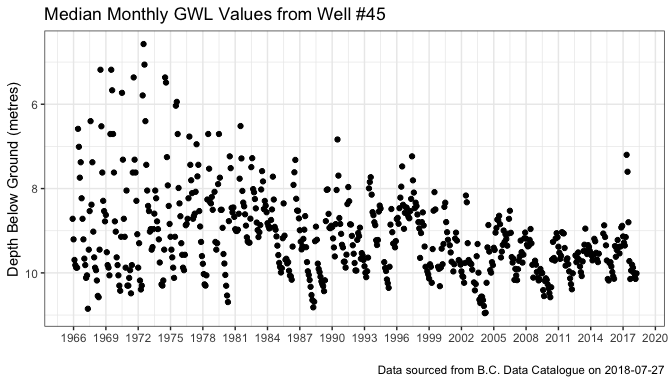

```r
# calculate the median monthly values
monthly_data <- monthly_values(data) %>%
  mutate(Date = as.Date(Date))

# visualise the monthly time-series data
ggplot(monthly_data, aes(Date, med_GWL)) +
  geom_point() +
  scale_x_date(date_breaks = "3 year", date_labels = "%Y") +
  scale_y_reverse() +
  theme_bw() +
  labs(title = paste0("Median Monthly GWL Values from Well #", well),
       caption = paste0("\nData sourced from B.C. Data Catalogue on ", Sys.Date()),
       x = NULL,
       y = "Depth Below Ground (metres)")
```

Generate & visualise a full montly time series with no gaps in dates:

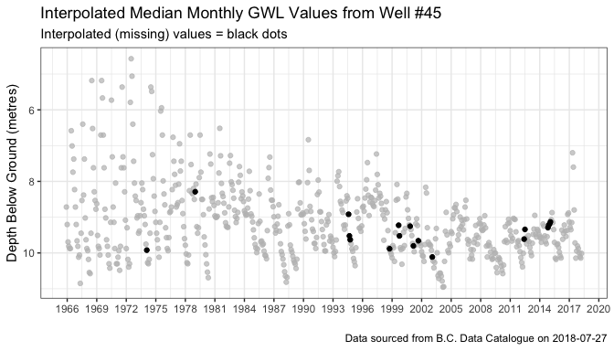

```r
# interpolate missing median monthly values
full_monthly_data <- make_well_ts(monthly_data, trim=FALSE)

# visualise the interpolated data in the time-series with gghighlight
ggplot(full_monthly_data, aes(Date, med_GWL)) +
  geom_point() +
  gghighlight(nReadings == "0") +
  scale_x_date(date_breaks = "3 year", date_labels = "%Y") +
  scale_y_reverse() +
  theme_bw() +
  theme(legend.position="none") +
  labs(title = paste0("Interpolated Median Monthly GWL Values from Well #", well),
       subtitle = "Interpolated (missing) values = black dots",
       caption = paste0("\nData sourced from B.C. Data Catalogue on ", Sys.Date()),
       x = NULL,
       y = "Depth Below Ground (metres)")
```

Generate some summary information—with the [`dplyr` package](https://dplyr.tidyverse.org/)—about the time-series dataset to help you decide if it is appropriate to conduct a long-trend analysis (e.g. 10+ years data? Not too many missing median monthly values?):

```r
full_monthly_data %>%
  group_by(Well_Num) %>%
  summarise(dataStart = as.Date(min(Date)),
            dataEnd = as.Date(max(Date)),
            dataYears = as.numeric(dataEnd - dataStart) / 365,
            nObs = n(),
            nMissing = length(med_GWL[nReadings == 0]),
            percent_missing = round(nMissing/nObs*100, 1)) %>%
  select(Well_Num, dataYears, dataEnd, nMissing, percent_missing)
```

```
## # A tibble: 1 x 5
##   Well_Num dataYears dataEnd    nMissing percent_missing
##   <chr>        <dbl> <date>        <int>           <dbl>
## 1 045           52.4 2018-04-01       18             2.9
```

## Mann-Kendall Trend Test

Calculate mean annual values, implement a Mann-Kendall trend test and visualise the results:

```r
#calculate mean annual values
annual_data <- full_monthly_data %>%
  select(-yearmonth) %>%
  group_by(EMS_ID, Well_Num, Year) %>%
  summarize(nReadings = n(),
            mean_GWL = mean(med_GWL),
            SD = sd(med_GWL),
            med_GWL = median(med_GWL),
            q95_GWL = quantile(med_GWL, 0.95),
            n_months = n()) %>%
  mutate(Date = as.Date(paste0(Year,"-01-01")))

#Mann-Kendall trend test using result from the yuepilon method
result <- gwl_zyp_test(annual_data, byID = "Well_Num", col = "mean_GWL") %>%
  filter(test_type == "yuepilon")
result
```

```
##   Well_Num test_type     lbound      trend   trendp     ubound       tau
## 1      045  yuepilon 0.01646377 0.02385985 1.288432 0.03052652 0.4354136
##            sig nruns   autocor valid_frac     linear intercept
## 1 4.291534e-06     1 0.1566948          1 0.02418578  8.452316
```

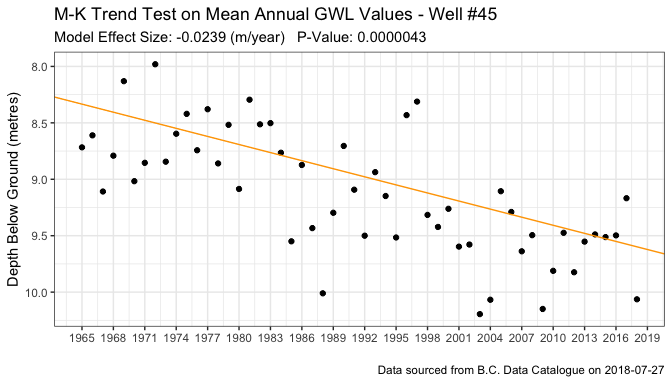

```r
#visualise the data & Mann-Kendall results
ggplot(annual_data) +
  geom_point(aes(Date, mean_GWL)) +
  geom_abline(data = result, intercept = -result$intercept, slope = -(result$trend/365),
              colour = "orange") +
  scale_x_date(date_breaks = "3 year", date_labels = "%Y") +
  scale_y_reverse() +
  theme_bw() +
  labs(title = paste0("M-K Trend Test on Mean Annual GWL Values - Well #",
                      well),
       subtitle = paste0("Model Effect Size: ", signif(-result$trend, digits = 3),
                         " (m/year)   P-Value: ", format(signif(result$sig, digits = 2),
                                                         scientific = FALSE)),
       caption = paste0("\nData sourced from B.C. Data Catalogue on ",
                        Sys.Date()),
       x = NULL,
       y = "Depth Below Ground (metres)")
```

## Seasonal Kendall Trend Test

Ensure complete set of median monthly values for each year and implement a Seasonal Kendall trend test:

```r
# use years with all (12) months data
full_monthly_data_comp_yrs <- full_monthly_data %>%
  group_by(Year) %>%
  filter(n() == 12) %>%
  ungroup()

#seasonal-K trend test
sk <- kendallSeasonalTrendTest(med_GWL ~ Month + Year,
                               data = full_monthly_data_comp_yrs)
print(sk)
```

```
##
## Results of Hypothesis Test
## --------------------------
##
## Null Hypothesis:                 All 12 values of tau = 0
##
## Alternative Hypothesis:          The seasonal taus are not all equal
##                                  (Chi-Square Heterogeneity Test)
##                                  At least one seasonal tau != 0
##                                  and all non-zero tau's have the
##                                  same sign (z Trend Test)
##
## Test Name:                       Seasonal Kendall Test for Trend
##                                  (with continuity correction)
##
## Estimated Parameter(s):          tau       =   0.26967069
##                                  slope     =   0.02087689
##                                  intercept = -25.68254484
##
## Estimation Method:               tau:        Weighted Average of
##                                              Seasonal Estimates
##                                  slope:      Hirsch et al.'s
##                                              Modification of
##                                              Thiel/Sen Estimator
##                                  intercept:  Median of
##                                              Seasonal Estimates
##
## Data:                            y      = med_GWL
##                                  season = Month
##                                  year   = Year
##
## Data Source:                     full_monthly_data_comp_yrs
##
## Sample Sizes:                    1     =  52
##                                  2     =  52
##                                  3     =  52
##                                  4     =  52
##                                  5     =  52
##                                  6     =  52
##                                  7     =  52
```

[output cut: 11 more lines]

```
##
## P-values:                        Chi-Square (Het) = 0.00000e+00
##                                  z (Trend)        = 1.46561e-22
##
## Confidence Interval for:         slope
##
## Confidence Interval Method:      Gilbert's Modification of
##                                  Theil/Sen Method
##
## Confidence Interval Type:        two-sided
##
## Confidence Level:                95%
##
## Confidence Interval:             LCL = 0.01661404
##                                  UCL = 0.02569636
```

Pull out the various result statistics and visualise:

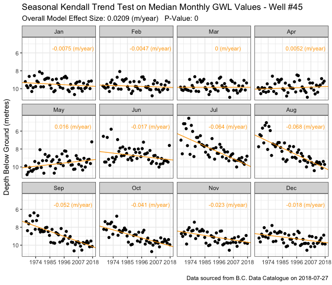

```r
# overall seasonal model effect size
sk_slope <- sk[["estimate"]][["slope"]]

# overall seasonal model significance
sk_sig <- sk[["p.value"]][["z (Trend)"]]

# put seasonal estimates into a dataframe with Month column
s_est <- as.data.frame(sk$seasonal.estimates)
s_est <- rowid_to_column(s_est, "Month")

# calculate seasonal y-intercepts
s_est$corr_int <- -(s_est$intercept +
                      s_est$slope *
                      as.numeric(format(min(full_monthly_data_comp_yrs$Date), "%Y")))

# create month labels facets in plot
month.abb2 <- setNames(month.abb, as.character(1:12))

# plot seasonal M-K trend results
ggplot(full_monthly_data_comp_yrs) +
  geom_point(data = , aes(Date, med_GWL)) +
  geom_abline(data = s_est,
              aes(intercept = s_est$corr_int,
                  slope = -s_est$slope/365), colour = "orange") +
  geom_text(data = s_est,
            aes(label = paste0(signif(-s_est$slope, digits = 2), " (m/year)" )),
            x = 12000, y = -5.5,
            size = 3, colour = "orange") +
  facet_wrap(~Month, labeller = as_labeller(month.abb2)) +
  scale_x_date(date_breaks = "11 year", date_labels = "%Y") +
  scale_y_reverse() +
  theme_bw() +
  labs(title = paste0("Seasonal Kendall Trend Test on Median Monthly GWL Values - Well #",
                      well),
       subtitle = paste0("Overall Model Effect Size: ",
                         signif(sk_slope, digits = 3),
                         " (m/year)   P-Value: ",
                         format(round(sk_sig, digits = 2),
                                scientific = FALSE)),
       caption = paste0("\nData sourced from B.C. Data Catalogue on ",
                        Sys.Date()),
       x = NULL,
       y = "Depth Below Ground (metres)")
```

2018-07-27